사용데이터 : https://2stndard.tistory.com/68

## 축 범위 설정

`ggplot2`로 그린 그래프의 세부 조정 과정중에 많이 사용하는 방법이 축의 범위를 설정하는 것이다. 일반적으로 축의 범위는 `ggplot2`에서 자동적으로 설정하는데 이 범위는 `ggplot2`에서 설정된 기하요소(`geom_*()`)들이 가장 잘 표현될 수 있는 여백을 설정한다. 아래의 그림은 `ggplot2`의 그래프에서 데이터가 표시되는 영역과 여백 영역을 보여준다.

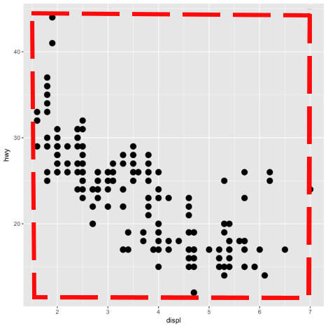

https://stackoverflow.com/questions/48049027/extend-ggplot2-geom-to-change-default-padding-of-x-and-y-axes

이 영역은 X축과 Y축의 범위를 조절함으로써 늘릴 수도 줄일 수도 있는데 축을 늘려주면 Zoom Out의 효과가 나타나고 축을 줄여주면 Zoom In 효과가 나타난다. `ggplot2`에서 축의 범위를 조절하기 위해서는 정확히 X, Y축의 최대, 최소값을 지정하여를 그 범위를 절대적으로 고정하는 방법과 입력된 데이터의 범위에 비례하여 유동적으로 설정하는 방법의 두 가지 방법으로 구분하여 알아본다.

축의 범위 설정을 알아보기 위해서 https://2stndard.tistory.com/68에서 사용한 졸업자 대비 취업자 산점도 그래프를 사용하겠다. 이 데이터는 X축의 범위가 1부터 489까지이고 Y축의 범위는 0부터 390까지이다.

```r
range(df_취업률_2000$졸업자수)
```

```
## [1]   1 489
```

```r
range(df_취업률_2000$취업자수)
```

```
## [1]   0 390
```

```r
df_취업률_2000 |>
  ggplot(aes(x = 졸업자수, y = 취업자수)) +
  geom_point() +
  scale_x_continuous(breaks = seq(0, 500, 75), labels = paste0(seq(0, 500, 75), '명')) +
  scale_y_continuous(breaks = c(50, 100, 200, 300), labels = c('50명', '100명', '200명', '300명'))
```

[figure not shown]

### X, Y의 최대, 최소값을 사용하여 절대적 고정 좌표계 설정

####좌표계 설정 함수 사용 : coord_cartesian()

`coord_cartesian()`은 `ggplot2`로 표현되는 전체 좌표계의 설정을 조절할 수 있는 함수이다. `ggplot2`에서 사용하는 좌표계는 우리가 가장 쉽게, 가장 흔히 사용하는 데카르트 좌표계(Cartesian Coordinate)이다. 이 좌표계는 X축과 Y축의 두 축을 사용하여 표현되는 좌표계인데 `coord_cartesian()`를 사용하면 X, Y축의 범위를 설정할 수 있다. `coord_cartesian()`에서 축의 범위를 설정하는데는 다음의 세 가지 매개변수가 사용된다.

- xlim : X축의 범위를 설정하는 매개변수로 X축의 최소값과 최대값을 가진 벡터를 설정함
- ylim : Y축의 범위를 설정하는 매개변수로 Y축의 최소값과 최대값을 가진 벡터를 설정함
- expand : 그래프에서 데이터를 온전하게 표시하기 위해 여백을 줄것인지를 설정함, TRUE이면 여백이 설정되고 FALSE이면 여백이 없이 전체 범위에 데이터가 표현된다.

아래는 졸업자수 대비 취업자수의 산점도에 X, Y축의 범위를 다시 설정하는 코드이다.

```r
df_취업률_2000 |>
  ggplot(aes(x = 졸업자수, y = 취업자수)) +
  geom_point() +
  scale_x_continuous(breaks = seq(0, 500, 75), labels = paste0(seq(0, 500, 75), '명')) +
  scale_y_continuous(breaks = c(50, 100, 200, 400), labels = c('50명', '100명', '200명', '400명')) +
  coord_cartesian(xlim = c(-100, 600), ylim = c(-100, 500))
```

[figure not shown]

```r
df_취업률_2000 |>
  ggplot(aes(x = 졸업자수, y = 취업자수)) +
  geom_point() +
  scale_x_continuous(breaks = seq(0, 500, 75), labels = paste0(seq(0, 500, 75), '명')) +
  scale_y_continuous(breaks = c(0, 50, 100, 200, 400), labels = c('0명', '50명', '100명', '200명', '400명')) +
  coord_cartesian(expand = FALSE)
```

[figure not shown]

#### scale_x_*(), scale_y_*() 함수의 사용

축의 설정에 가장 기본적으로 사용하는 함수는 `scale_x_*()`와 `scale_y_*()`이다. 위의 기본 산점도에서 보듯이 ’breaks’와 ’labels’를 사용해서 축의 눈금 라벨을 설정하는 등 많은 설정을 할 수 있는데 축의 범위를 설정할 수도 있다.

축의 범위를 설정하기 위해서는 `scale_x_*()`와 `scale_y_*()`의 ‘limits’ 매개변수를 사용한다. ’limits’는 다음의 세가지 값을 가진다.

- NULL : X, Y축의 기본값을 사용
- 수치형 벡터 : 축의 최소값과 최대값을 가지는 수치형 벡터
- 함수 : 데이터의 분포에 따라 축의 최대값과 최소값을 리턴하는 함수

이번에는 축의 범위를 좁혀서 Zoom In 효과로 일부 구간을 확대해 본다.

```r
df_취업률_2000 |>
  ggplot(aes(x = 졸업자수, y = 취업자수)) +
  geom_point() +
  scale_x_continuous(breaks = seq(0, 500, 75), labels = paste0(seq(0, 500, 75), '명'), limits = c(75, 150)) +
  scale_y_continuous(breaks = c(0, 50, 100, 200, 400), labels = c('0명', '50명', '100명', '200명', '400명'), limits = c(50, 100))
```

[figure not shown]

#### 축 범위 설정 함수 사용 : xlim(), ylim()

`scale_x_*()`, `scale_y_*()`, `coord_cartesian()`를 사용하여 설정이 가능하겠지만 축의 범위를 설정하는 일이 잦기 때문에 `ggplot2`에서는 축의 범위를 설정하는 래핑 함수를 제공한다. 이 함수가 `xlim()`과 `ylim()`이다. 이 함수들에 최소값, 최대값을 직접 설정하여 사용한다. 만약 NA를 설정하면 `ggplot2`의 기본 설정 범위가 설정된다.

```r
df_취업률_2000 |>
  ggplot(aes(x = 졸업자수, y = 취업자수)) +
  geom_point() +
  scale_x_continuous(breaks = seq(0, 500, 75), labels = paste0(seq(0, 500, 75), '명')) +
  scale_y_continuous(breaks = c(0, 50, 100, 200, 400), labels = c('0명', '50명', '100명', '200명', '400명')) +
  xlim(75, 150) +
  ylim(50, 100)
```

[figure not shown]

### X, Y의 범위 비율을 사용하여 상대적 좌표계 설정

앞서 살펴본 좌표계 설정은 축의 범위를 절대적으로 설정하기 때문에 주어지는 데이터에 따라 그 범위가 적절치 않을 수 있다. 1회성 그래프를 그릴 때는 절대적 좌표계를 설정해서 사용할 수 있겠지만 Shiny 패키지로 동적 분석 앱을 만들때 절대적 좌표계를 설정하면 데이터 를 적절히 표현하기 어렵다. 이럴 경우 데이터가 표현되는 범위를 비율로 설정해서 사용하면 효율적인 시각화가 된다.

#### scale_x_*(), scale_y_*()의 expand 사용

X축과 Y축의 범위를 비율을 사용하여 설정하기 위해서는 `scale_x_*()`와 `scale_y_*()`에서 ‘expand’ 매개변수를 사용해서 설정한다. ’expand’는 두개의 수치를 가진 벡터로 설정하는데 앞의 수치는 양쪽으로 확장되는 곱셈 비율이고 뒤의 수치는 양쪽으로 더해지는 값의 범위이다. 만약 아래와 같이 ’expand’를 ’c(0.5, 100)’으로 설정하면 양쪽으로 50%씩 확장되고 양쪽으로 100씩 더해지는 범위를 가지게 된다.

이를 계산해보면 X축의 볌위가 대략 1부터 500까지이므로 곱셈 비율에 의해 양쪽으로 50%인 250씩 늘어나고 여기에 100씩 더 늘어나니 전체 축의 범위는 대략적으로 -350부터 850까지가 된다.

```r
df_취업률_2000 |>
  ggplot(aes(x = 졸업자수, y = 취업자수)) +
  geom_point() +
  scale_x_continuous(breaks = seq(-300, 800, 50), expand = c(0.5, 100)) +
  scale_y_continuous(breaks = c(0, 50, 100, 200, 400), labels = c('0명', '50명', '100명', '200명', '400명'))
```

[figure not shown]

#### scale_x_*(), scale_y_*()의 expansion() 사용

위에서 expand 매개변수를 사용하여 축의 양쪽 확장 비율과 확장 범위를 설정할 수 있지만 만약 확장 비율을 양쪽으로 달리 줘야한다면 어떻게 할까? 또 확장 범위를 양쪽으로 달리하고자 한다면 어떻게 할까? 이를 위해 `ggplot2`에서는 `expansion()`을 제공한다.

`expansion()`은 mult와 add의 두 가지 매개변수를 가진다.

- mult : 확장에 사용할 비율을 수치로 설정함. 단일 수치로 설정하면 양쪽으로 동일한 비율로 확장되며 길이가 2인 벡터로 설정하면 하위값과 상위값으로의 비율을 따로 설정할 수 있음.
- add : 확장에 사용할 범위를 수치로 설정함. 단일 수치로 설정하면 양쪽으로 동일한 범위로 확장되며 길이가 2인 벡터로 설정하면 하위값과 상위값으로 범위를 따로 설정할 수 있음.

아래의 코드는 `expansion()`으로 X축은 비율로 최소값쪽으로 30%, 최대값쪽으로 70%를 확장하고 Y축은 범위로 최소값쪽으로 50명, 최대값쪽으로 100명 만큼 확장하는 코드이다.

```r
df_취업률_2000 |>
  ggplot(aes(x = 졸업자수, y = 취업자수)) +
  geom_point() +
  scale_x_continuous(expand = expansion(mult = c(0.3, 0.7))) +
  scale_y_continuous(expand = expansion(add = c(50, 100)))
```

[figure not shown]

만약 비율이나 범위를 마이너스로 설정하면 확장이 아닌 축소가 된다. 아래는 X축에는 양쪽이 20%씩 축소되고 Y축으로는 100명씩 축소된 축으로 설정하는 코드이다.

```r
df_취업률_2000 |>
  ggplot(aes(x = 졸업자수, y = 취업자수)) +
  geom_point() +
  scale_x_continuous(expand = expansion(mult = -0.2)) +
  scale_y_continuous(expand = expansion(add = -100))
```

[figure not shown]